# Take-home Exercise 1

In this Take-home Exercise 1, I will be exploring and revealing the demographic of the city of Engagement, Ohio USA by using appropriate static statistical graphics methods.

Clarence Tay https://www.linkedin.com/in/clarencetay/ (Singapore Management University - School of Computing and Information Systems)https://scis.smu.edu.sg/  
2022-04-23

# Overview

In this take-home exercise, I will be exploring and revealing the demographic of the city of Engagement, Ohio USA by using appropriate static statistical graphics methods. The data will be processed by using appropriate tidyverse family of packages and the statistical graphics will be done with ggplot2 and its extensions. Datasets used will be taken from the VAST challenge 2022.

# Getting Started

Before we get started, it is important for us to ensure that the required R packages have been installed. If yes, we will load the R packages. If they have yet to be installed, we will install the R packages and load them onto R environment.

# Importing Data

The code chunk below imports *Participants.csv* from the data folder, into R by using [`read_csv()`](https://readr.tidyverse.org/reference/read_delim.html) of [**readr**](https://readr.tidyverse.org/) and save it as an tibble dataframe called *participants_data*.

```r
participants_data = read_csv("data/Participants.csv")
```

```r
colnames(participants_data)
```

```
[1] "participantId"  "householdSize"  "haveKids"
[4] "age"            "educationLevel" "interestGroup"
[7] "joviality"
```

```r
count(participants_data)
```

```
# A tibble: 1 x 1
      n
  <int>
1  1011
```

```r
count(participants_data,educationLevel)
```

```
# A tibble: 4 x 2
  educationLevel          n
  <chr>               <int>
1 Bachelors             232
2 Graduate              170
3 HighSchoolOrCollege   525
4 Low                    84
```

```r
count(participants_data,householdSize)
```

```
# A tibble: 3 x 2
  householdSize     n
          <dbl> <int>
1             1   337
2             2   373
3             3   301
```

```r
count(participants_data,interestGroup)
```

```
# A tibble: 10 x 2
   interestGroup     n
   <chr>         <int>
 1 A               102
 2 B                91
 3 C               102
 4 D                96
 5 E                83
 6 F               106
 7 G               108
 8 H               111
 9 I                96
10 J               116
```

```r
min(participants_data$age)
```

```
[1] 18
```

```r
max(participants_data$age)
```

```
[1] 60
```

```r
min(participants_data$joviality)
```

```
[1] 0.000204
```

```r
max(participants_data$joviality)
```

```
[1] 0.999234
```

# A Simple Bar Chart

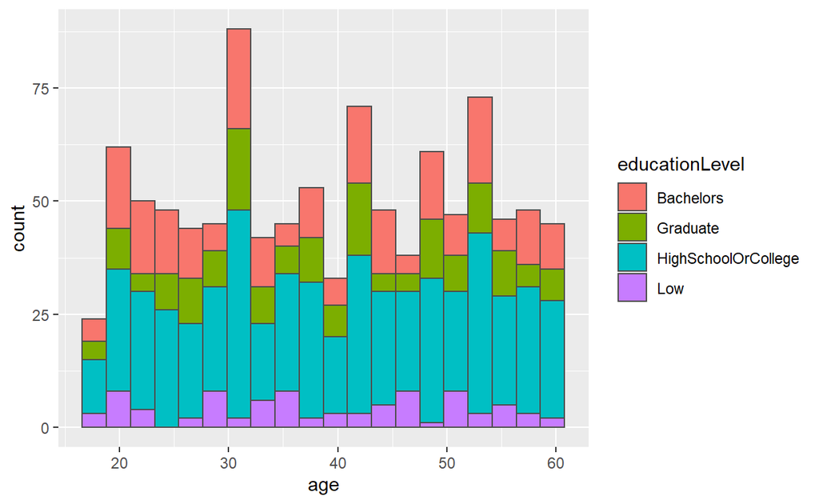

```r
ggplot(data = participants_data,
       aes(x=age, fill= educationLevel)) +
  geom_histogram(bins=20, color='grey30')
```

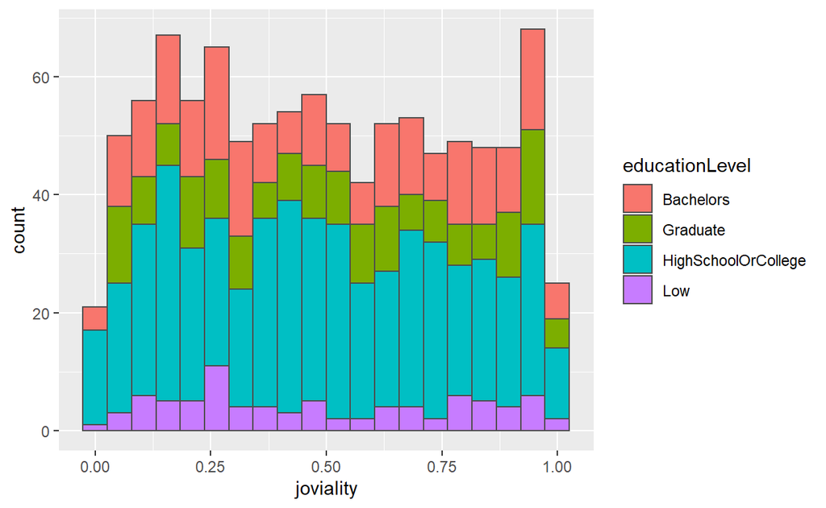

```r
ggplot(data = participants_data,
       aes(x=joviality, fill= educationLevel)) +
  geom_histogram(bins=20, color='grey30')
```

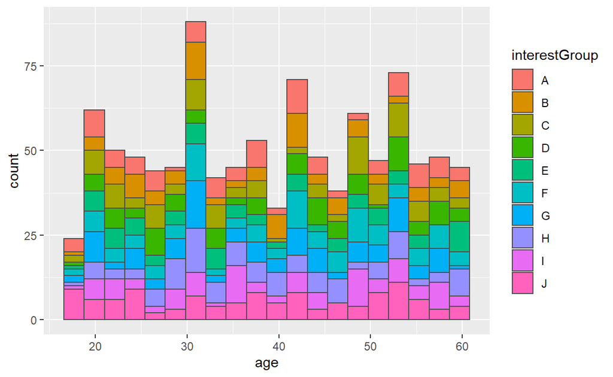

```r
ggplot(data = participants_data,
       aes(x=age, fill= interestGroup)) +
  geom_histogram(bins=20, color='grey30')
```

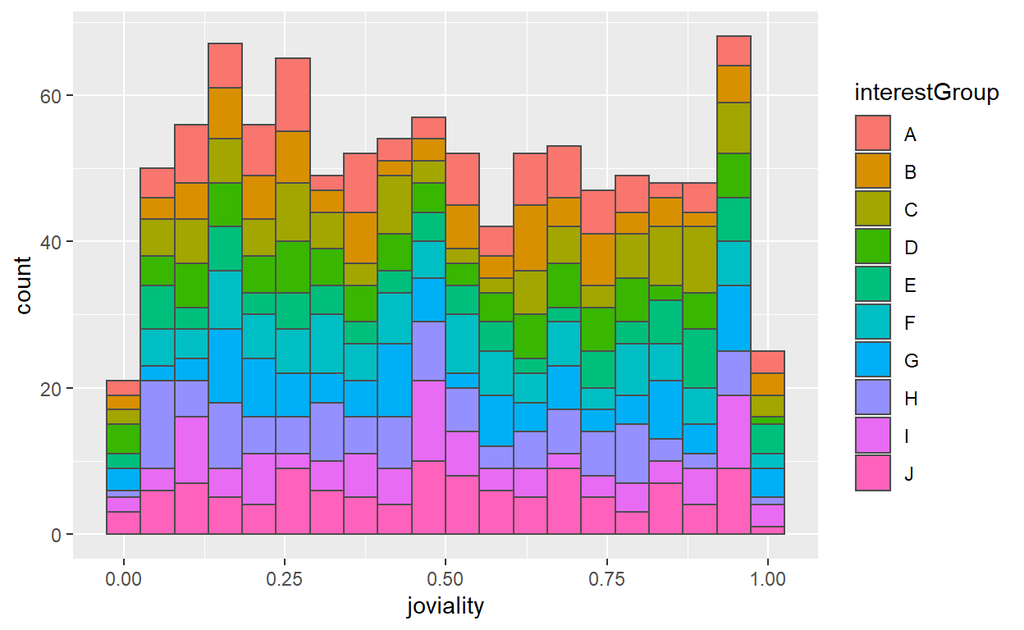

```r
ggplot(data = participants_data,
       aes(x=joviality, fill= interestGroup)) +
  geom_histogram(bins=20, color='grey30')
```

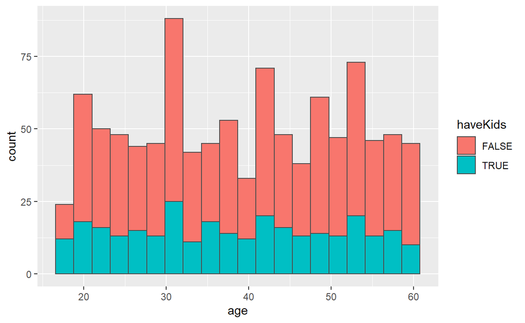

```r
ggplot(data = participants_data,
       aes(x=age, fill= haveKids)) +
  geom_histogram(bins=20, color='grey30')
```

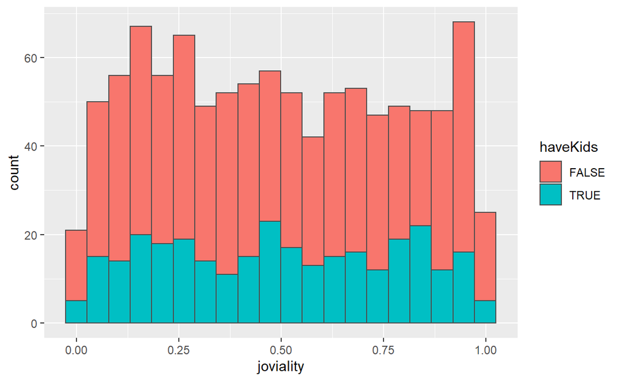

```r
ggplot(data = participants_data,
       aes(x=joviality, fill= haveKids)) +
  geom_histogram(bins=20, color='grey30')
```

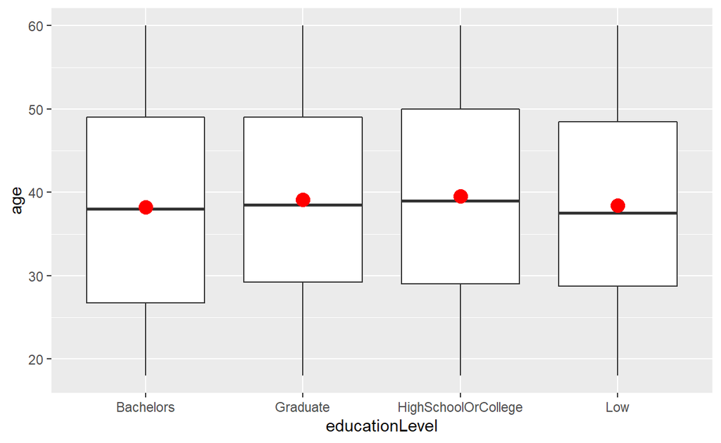

```r
ggplot(data = participants_data,
       aes(y=age, x= educationLevel)) +
  geom_boxplot() +
  geom_point(stat='summary',
             fun.y='mean',
             colour='red',
             size=4)
```

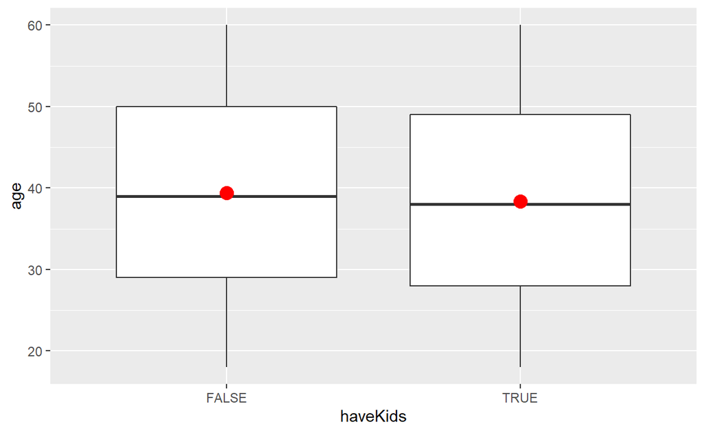

```r
ggplot(data = participants_data,
       aes(y=age, x= haveKids)) +
  geom_boxplot() +
  geom_point(stat='summary',
             fun.y='mean',
             colour='red',
             size=4)
```

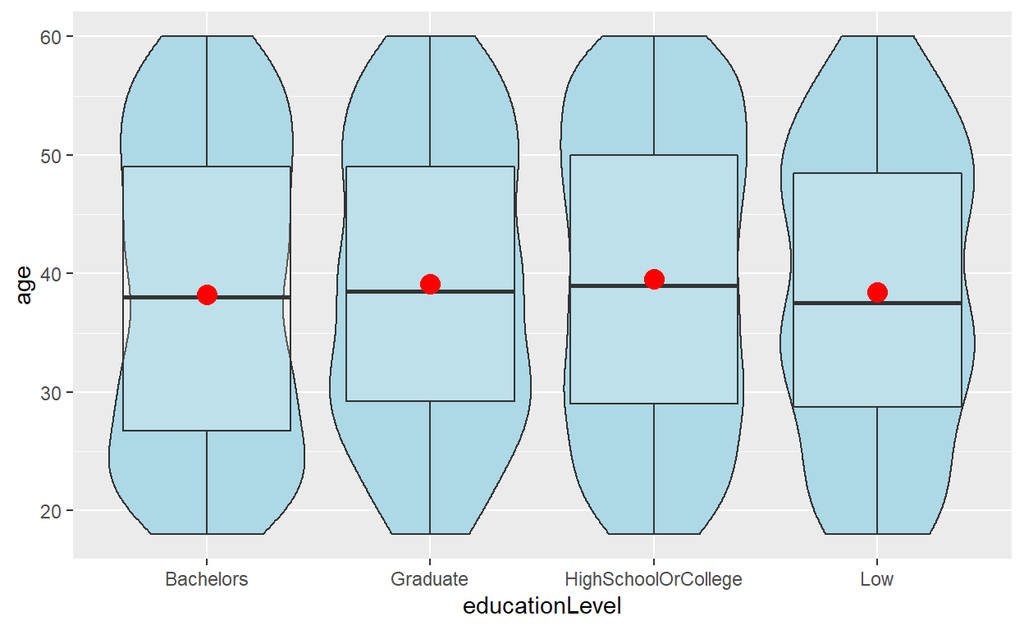

```r
ggplot(data = participants_data,
       aes(y=age, x= educationLevel)) +
  geom_violin(fill='light blue') +
  geom_boxplot(alpha=0.2) +
  geom_point(stat='summary',
             fun.y='mean',
             colour='red',
             size=4)
```

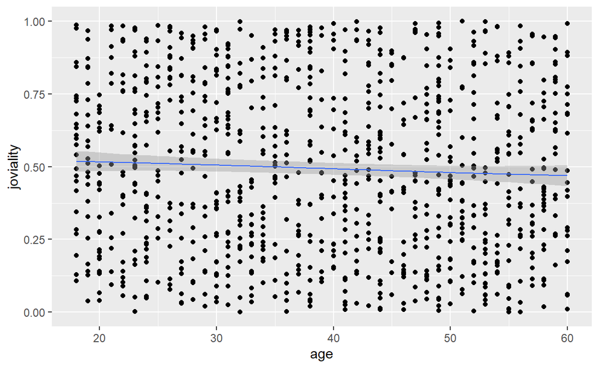

```r
ggplot(data = participants_data,
         aes(x=age, y= joviality)) +
  geom_point() +
  geom_smooth(size=0.5)
```

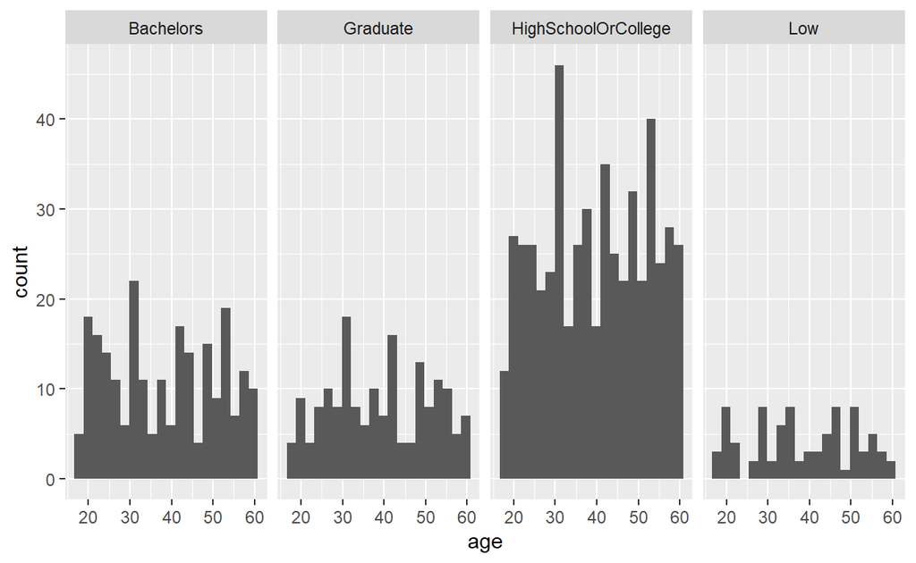

```r
ggplot(data = participants_data,
         aes(x=age)) +
  geom_histogram(bins=20) +
  facet_grid(~educationLevel)
```

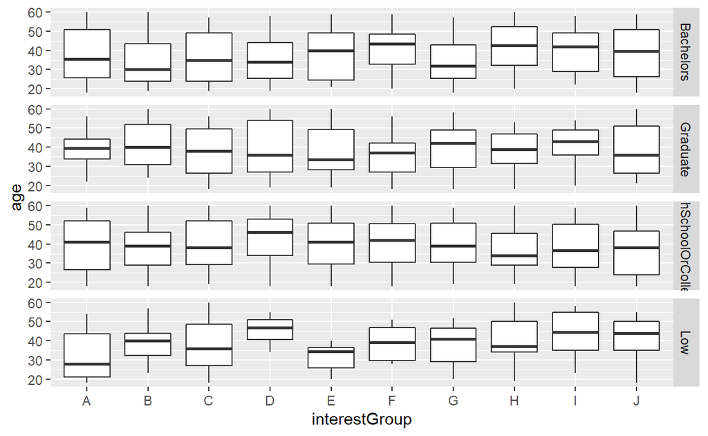

```r
ggplot(data = participants_data,
         aes(y=age, x = interestGroup)) +
  geom_boxplot() +
  facet_grid(educationLevel~.)
```

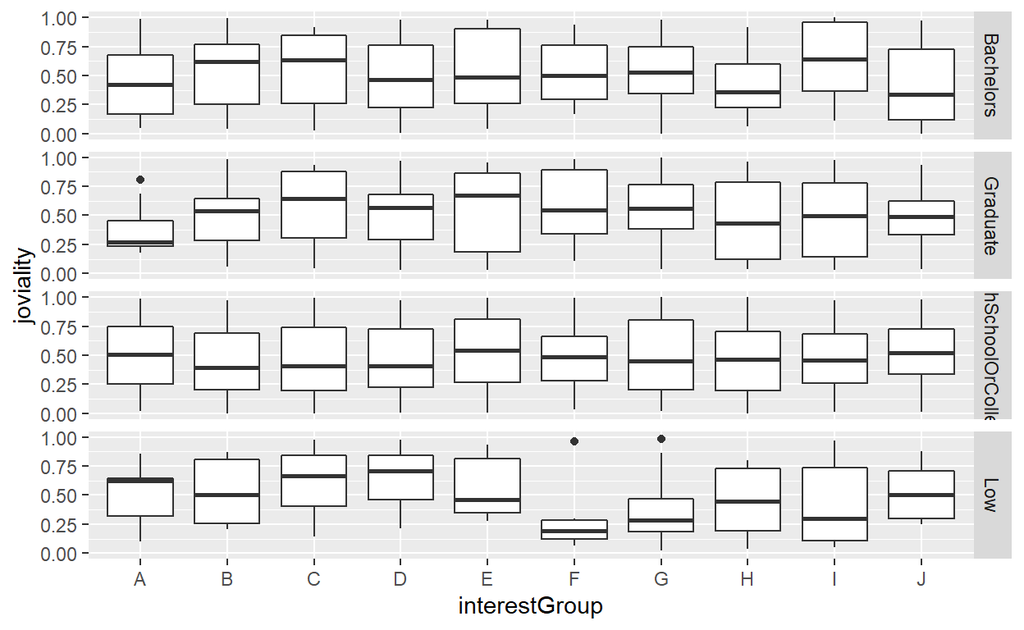

```r
ggplot(data = participants_data,
         aes(y=joviality, x = interestGroup)) +
  geom_boxplot() +
  facet_grid(educationLevel~.)
```

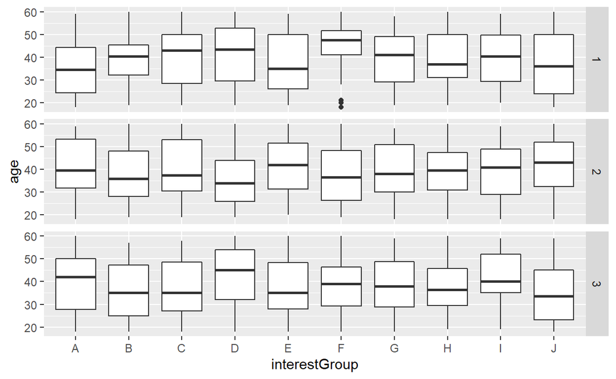

```r
ggplot(data = participants_data,
         aes(y=age, x = interestGroup)) +
  geom_boxplot() +
  facet_grid(householdSize~.)
```

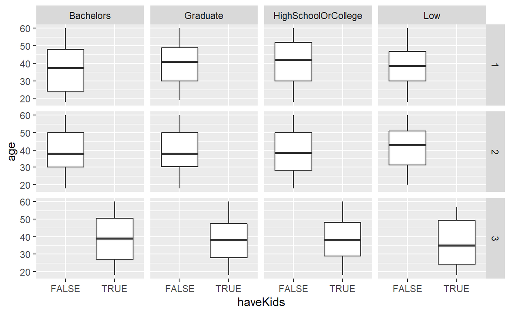

```r
ggplot(data = participants_data,
         aes(y=age, x = haveKids)) +
  geom_boxplot() +
  facet_grid(householdSize~educationLevel)
```

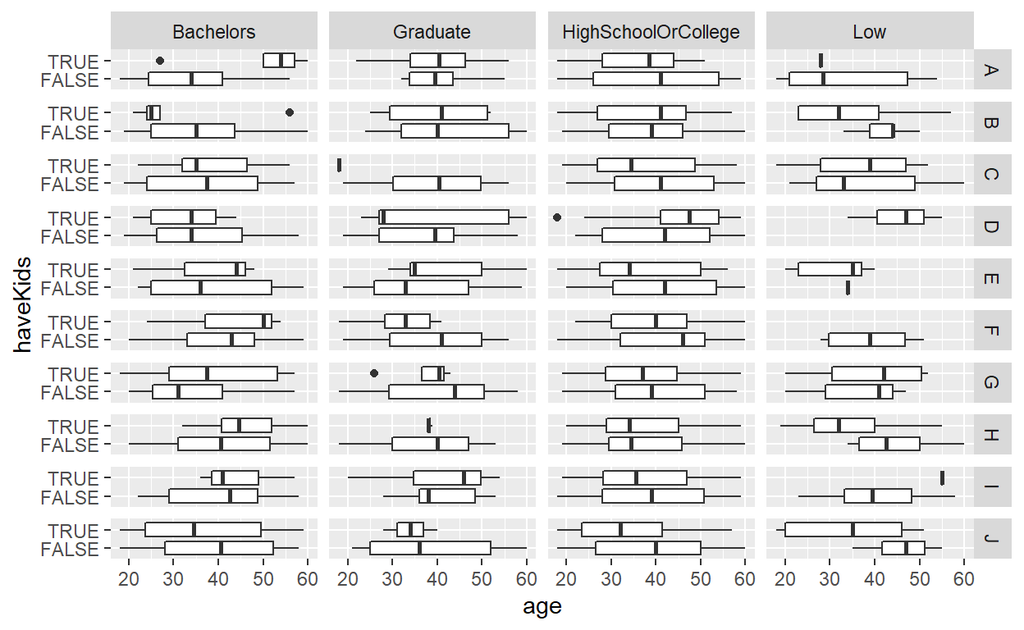

```r
ggplot(data = participants_data,
         aes(y=age, x = haveKids)) +
  geom_boxplot() +
  facet_grid(interestGroup~educationLevel) +
  coord_flip()
```

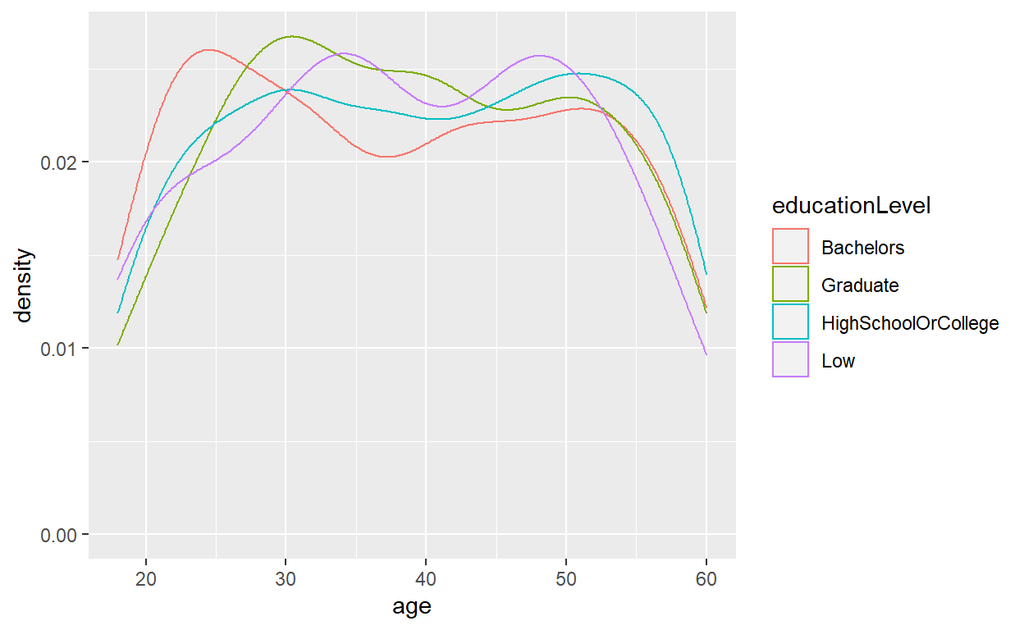

```r
ggplot(data = participants_data,
         aes(x=age, colour = educationLevel)) +
  geom_density()
```